# TOG workshop: most common statistical tests in R

Jeff Bone

23/02/2022

# Oveview

- Background on statistical tests, p-values and confidence intervals
- Types of tests: depends on outcomes
- Examples of common tests, programming and output

# Hypothesis testing

- Scientific hypothesis can be translated into statistical hypothesis/statements
- Statistical hypothesis testing provides estimates for the magnitude and certainty we have for a scientific hypothesis
- Key is usually is to ask how consistent our data is with a specified hypothesis

# Hypothesis testing

- Usually we frame our statistical hypotheses in terms of a ‘null’ and ‘alternative’ hypothesis
- Null: there is no effect/change in what we are measuring
- Alternative: there is some change (increase, decrease, etc) in whatever we are measuring
- Sometimes denoted $H_0$ and $H_A$

# Hypothesis testing

1. Generate hypothesis
2. Collect data
3. Test hypothesis
4. Interpret results

Sometimes 1 and 2 are flipped

Key is usually in 4 - must be combination of background and statistical output

# Types of errors

1. Type 1 error: probability of rejecting the null hypothesis when the null hypothesis is actually true.
2. Type 2 error: probability of failing to rejecting the null hypothesis when it is false

Note: statistical power is 1-Type 2 error, i.e. probability of correctly identifying a true effect.

# p-values

- Most commonly used way of hypothesis testing
- Controversial, often overused, misinterpreted, but pervasive
- Informally, the p-value is the probability under a specified statistical model that a statistical summary of the data would be equal to or more extreme than its observed value
- Often use a cutoff of 0.05 or 5%

# p-values

**DOES**:

- Indicate how incompatible data are with a prespecified statistical model. E.g., model in which two groups have the same outcome

**DOES NOT**:

- Give the probability of the null hypothesis being true!
- Measure the size of the effect/association!
- Exist in a vacuum!

‘Whenever a researcher chooses what to present based on statistical results, valid interpretation of those results is severely compromised if the reader is not informed of the choice and its basis’

# Confidence interval

- Hypothesis tests are meant to look for a statistical difference
- These differences have uncertainty
- Confidence interval shows range of differences data is compatible with
- Small p-value = more narrow confidence interval

# Hypothesis testing: Presenting results

1. Summary data
2. Difference (absolute or relative or both)
3. Confidence interval for difference
4. p-value

# Types of tests

- Depends on the outcome and exposure type (continuous, binary etc)
- Parametric vs nonparametric
- In general most ‘simple’ tests can be extended to or are very similar to regression models

# Continuous outcomes

When outcome is continuous we have a few options:

1. T-tests (binary exposure)
2. ANOVA (categorical exposure)
3. Correlation coefficients (continuous exposure)
4. Linear regression models (any exposure)

# T-tests

Test for difference in means between two groups (can be paired or unpaired)

Here is some data in R for two groups for a sleep experiment

```r
str(sleep) #examine data
```

```
## 'data.frame':    20 obs. of  3 variables:
##  $ extra: num  0.7 -1.6 -0.2 -1.2 -0.1 3.4 3.7 0.8 0 2 ...
##  $ group: Factor w/ 2 levels "1","2": 1 1 1 1 1 1 1 1 1 1 ...
##  $ ID   : Factor w/ 10 levels "1","2","3","4",..: 1 2 3 4 5 6 7 8 9 10 ...
```

```r
head(sleep)
```

```
##   extra group ID
## 1   0.7     1  1
## 2  -1.6     1  2
## 3  -0.2     1  3
## 4  -1.2     1  4
## 5  -0.1     1  5
## 6   3.4     1  6
```

# T-tests

```r
sleep %>%
  group_by(group) %>%
  get_summary_stats(extra, type =  c('common')) #get summary statistics in each group
```

```
## # A tibble: 2 x 11
##   group variable     n   min   max median   iqr  mean    sd    se    ci
##   <fct> <chr>    <dbl> <dbl> <dbl>  <dbl> <dbl> <dbl> <dbl> <dbl> <dbl>
## 1 1     extra       10  -1.6   3.7   0.35  1.88  0.75  1.79 0.566  1.28
## 2 2     extra       10  -0.1   5.5   1.75  3.28  2.33  2.00 0.633  1.43
```

# T-tests

To run a t-test in R, we can use `t.test()` function, which takes two vectors (group 1 and group 2) and a command ‘paired’

```r
group1 <- sleep %>% filter(group == 1)
group2 <- sleep %>% filter(group == 2)

t.test(group1$extra, group2$extra, paired = TRUE)
```

```
##
##  Paired t-test
##
## data:  group1$extra and group2$extra
## t = -4.0621, df = 9, p-value = 0.002833
## alternative hypothesis: true difference in means is not equal to 0
## 95 percent confidence interval:
##  -2.4598858 -0.7001142
## sample estimates:
## mean of the differences
##                   -1.58
```

# Aside: broom package

As we can see, the output from `t.test()` is a bit messy to work with. Luckily R has the wonderful ‘broom’ package, which works with all sorts of tests/regression models to ‘clean-up’ output.

```r
t.test(extra ~ group, data = sleep, paired = TRUE) %>% #here we use formula in t.test, rather than two vectors
  tidy()
```

```
## # A tibble: 1 x 8
##   estimate statistic p.value parameter conf.low conf.high method     alternative
##      <dbl>     <dbl>   <dbl>     <dbl>    <dbl>     <dbl> <chr>      <chr>
## 1    -1.58     -4.06 0.00283         9    -2.46    -0.700 Paired t-… two.sided
```

```r
t.test(extra ~ group, data = sleep, paired = TRUE) %>% #here we use formula in t.test, rather than two vectors
  tidy() %>%
  kable() %>%
  kable_styling()
```

| estimate | statistic | p.value | parameter | conf.low | conf.high | method | alternative |
| --- | --- | --- | --- | --- | --- | --- | --- |
| -1.58 | -4.062128 | 0.0028329 | 9 | -2.459886 | -0.7001142 | Paired t-test | two.sided |

# ANOVA

When there are more than 2 groups - the extension of a t-test is an ANOVA (analysis of variance), which tests for if at least two means differ between groups.

Here we use the iris data set

```
## 'data.frame':    150 obs. of  5 variables:
##  $ Sepal.Length: num  5.1 4.9 4.7 4.6 5 5.4 4.6 5 4.4 4.9 ...
##  $ Sepal.Width : num  3.5 3 3.2 3.1 3.6 3.9 3.4 3.4 2.9 3.1 ...
##  $ Petal.Length: num  1.4 1.4 1.3 1.5 1.4 1.7 1.4 1.5 1.4 1.5 ...
##  $ Petal.Width : num  0.2 0.2 0.2 0.2 0.2 0.4 0.3 0.2 0.2 0.1 ...
##  $ Species     : Factor w/ 3 levels "setosa","versicolor",..: 1 1 1 1 1 1 1 1 1 1 ...
```

```
##   Sepal.Length Sepal.Width Petal.Length Petal.Width Species
## 1          5.1         3.5          1.4         0.2  setosa
## 2          4.9         3.0          1.4         0.2  setosa
## 3          4.7         3.2          1.3         0.2  setosa
## 4          4.6         3.1          1.5         0.2  setosa
## 5          5.0         3.6          1.4         0.2  setosa
## 6          5.4         3.9          1.7         0.4  setosa
```

# ANOVA

```
## # A tibble: 3 x 11
##   Species    variable         n   min   max median   iqr  mean    sd    se    ci
##   <fct>      <chr>        <dbl> <dbl> <dbl>  <dbl> <dbl> <dbl> <dbl> <dbl> <dbl>
## 1 setosa     Sepal.Length    50   4.3   5.8    5   0.4    5.01 0.352 0.05  0.1
## 2 versicolor Sepal.Length    50   4.9   7      5.9 0.7    5.94 0.516 0.073 0.147
## 3 virginica  Sepal.Length    50   4.9   7.9    6.5 0.675  6.59 0.636 0.09  0.181
```

# ANOVA

Can use the `aov()` function. Here we have to use the formula argument

```r
aov(Sepal.Length ~ Species, data = iris) %>%
  tidy()
```

```
## # A tibble: 2 x 6
##   term         df sumsq meansq statistic   p.value
##   <chr>     <dbl> <dbl>  <dbl>     <dbl>     <dbl>
## 1 Species       2  63.2 31.6        119.  1.67e-31
## 2 Residuals   147  39.0  0.265       NA  NA
```

Kind of messy and would be nice to have the mean differences (not just sum of squares)

```r
aov(Sepal.Length ~ Species, data = iris) %>%
  tukey_hsd() #can use 'Tukey_hsd' function
```

```
## # A tibble: 3 x 9
##   term    group1     group2     null.value estimate conf.low conf.high    p.adj
## * <chr>   <chr>      <chr>           <dbl>    <dbl>    <dbl>     <dbl>    <dbl>
## 1 Species setosa     versicolor          0    0.93     0.686     1.17  3.39e-14
## 2 Species setosa     virginica           0    1.58     1.34      1.83  3   e-15
## 3 Species versicolor virginica           0    0.652    0.408     0.896 8.29e- 9
## # … with 1 more variable: p.adj.signif <chr>
```

# Correlation

When both outcome and exposure are continuous we might use a correlation coefficient (value between -1 and 1) to summarize the relationship.

Alternative is linear regression model

```r
cor.test(iris$Sepal.Width, iris$Sepal.Length) %>%
  tidy()
```

```
## # A tibble: 1 x 8
##   estimate statistic p.value parameter conf.low conf.high method     alternative
##      <dbl>     <dbl>   <dbl>     <int>    <dbl>     <dbl> <chr>      <chr>
## 1   -0.118     -1.44   0.152       148   -0.273    0.0435 Pearson's… two.sided
```

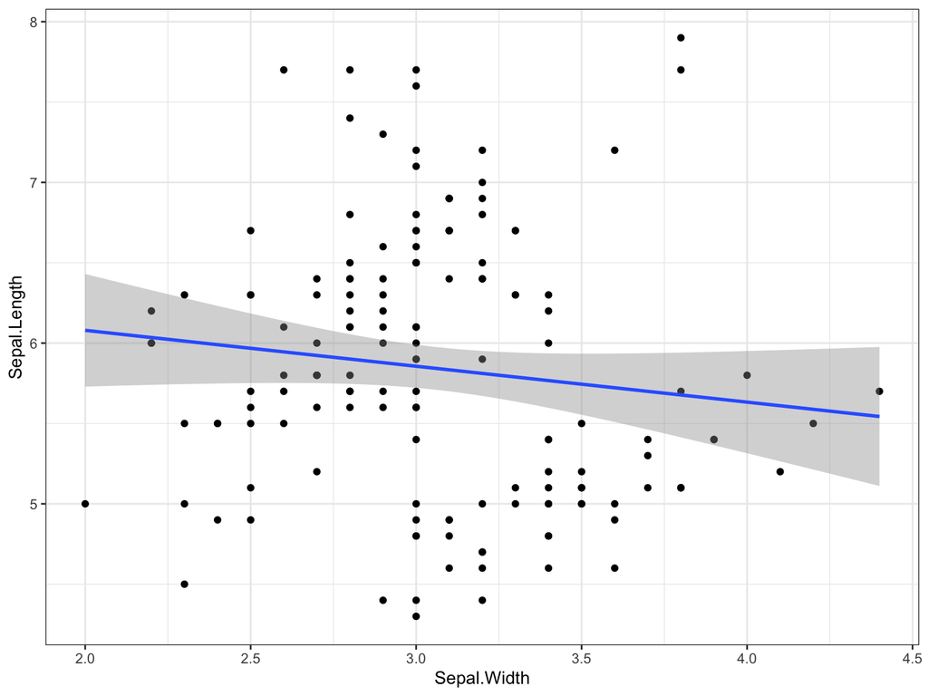

```r
iris %>%
  ggplot(aes(x = Sepal.Width, y= Sepal.Length)) +
  geom_point() +
  geom_smooth(method = 'lm') +
  theme_bw()
```

# TOG workshop: most common statistical tests in R part II

# Recap: Hypothesis testing

- Usually we frame our statistical hypotheses in terms of a ‘null’ and ‘alternative’ hypothesis
- Null: there is no effect/change in what we are measuring
- Alternative: there is some change (increase, decrease, etc) in whatever we are measuring

# Recap: Hypothesis testing

1. Generate hypothesis
2. Collect data
3. Test hypothesis
4. Interpret results

Sometimes 1 and 2 are flipped

Key is usually in 4 - must be combination of background and statistical output

# Recap: Hypothesis testing: Presenting results

1. Summary data
2. Difference (absolute or relative or both)
3. Confidence interval for difference
4. p-value

# Recap of tests

For testing and assessing relationship with a continuous outcome variable we can use:

1. t-tests: (binary predictor, paired or unpaired),
2. ANOVA (categorical predictor)
3. Correlation coefficients (continuous predictor)

# Today

- Discuss testing when outcome is binary (or categorical)
- Brief discussion of nonparametric tests
- Brief introduction to regression models

# Binary & Categorical variables

- When the outcome is binary - we no longer summarize things with means or mean differences.
- Usually one uses relative measures (e.g. risk or odds ratios)
- Tests for association are different than last time but presentation of results should be similar!

# Binary & Categorical variables

Have three main options for testing relationship between two categorical variables

1. Fisher exact test (good for small sample sizes, e.g. any cell size < 5)
2. $\chi^2$ test (good most of the time)
3. McNemar test (paired data)

Again, we want to look at summary data (contingency table) and then run test

# Example: two binary variables

```r
trt_dat <- read.csv("https://goo.gl/j6lRXD")

table(trt_dat$treatment, trt_dat$improvement)
```

```
##
##               improved not-improved
##   not-treated       26           29
##   treated           35           15
```

```r
table(trt_dat$treatment, trt_dat$improvement) %>% prop.table(margin = 1)
```

```
##
##                improved not-improved
##   not-treated 0.4727273    0.5272727
##   treated     0.7000000    0.3000000
```

```r
#or (longer)
trt_dat %>%
  group_by(treatment, improvement) %>%
  count() %>%
  spread(improvement, n)
```

```
## # A tibble: 2 x 3
## # Groups:   treatment [2]
##   treatment   improved `not-improved`
##   <chr>          <int>          <int>
## 1 not-treated       26             29
## 2 treated           35             15
```

# Effect estimates for binary outcomes

```
##   V1 V2
## 1  a  c
## 2  b  d
```

1. Odds ratio = (a/c)/(b/d)
2. Risk ratio = (a/(a+c))/(b/(b+d))

Both are fine to report - odds ratio somewhat more common due to statistical reasons.

When outcome is rare the OR is close to RR.

```r
table(trt_dat$treatment, trt_dat$improvement)
```

```
##
##               improved not-improved
##   not-treated       26           29
##   treated           35           15
```

```r
#compute OR
OR <- (26/29)/(35/15)
OR
```

```
## [1] 0.3842365
```

```r
RR <- (26/55)/(35/50)
RR
```

```
## [1] 0.6753247
```

# Two binary variables

```r
table(trt_dat$treatment, trt_dat$improvement)
```

```
##
##               improved not-improved
##   not-treated       26           29
##   treated           35           15
```

```r
fisher.test(trt_dat$treatment, trt_dat$improvement) %>%
  tidy()
```

```
## # A tibble: 1 x 6
##   estimate p.value conf.low conf.high method                         alternative
##      <dbl>   <dbl>    <dbl>     <dbl> <chr>                          <chr>
## 1    0.388  0.0289    0.158     0.921 Fisher's Exact Test for Count… two.sided
```

```r
chisq.test(trt_dat$treatment, trt_dat$improvement) %>% #doesnt give odds ratio etc
  tidy()
```

```
## # A tibble: 1 x 4
##   statistic p.value parameter method
##       <dbl>   <dbl>     <int> <chr>
## 1      4.66  0.0308         1 Pearson's Chi-squared test with Yates' continuity…
```

```r
#nice alternative is the riskratio or oddsratio function from the epitools package
library(epitools)

oddsratio(trt_dat$treatment, trt_dat$improvement)
```

```
## $data
##              Outcome
## Predictor     improved not-improved Total
##   not-treated       26           29    55
##   treated           35           15    50
##   Total             61           44   105
##
## $measure
##              odds ratio with 95% C.I.
## Predictor      estimate     lower     upper
##   not-treated 1.0000000        NA        NA
##   treated     0.3893128 0.1700086 0.8641452
##
## $p.value
##              two-sided
## Predictor     midp.exact fisher.exact chi.square
##   not-treated         NA           NA         NA
##   treated     0.02013718   0.02888541 0.01840777
##
## $correction
## [1] FALSE
##
## attr(,"method")
## [1] "median-unbiased estimate & mid-p exact CI"
```

```r
riskratio(trt_dat$treatment, trt_dat$improvement) #gives slightly different results to hand calculation
```

```
## $data
##              Outcome
## Predictor     improved not-improved Total
##   not-treated       26           29    55
##   treated           35           15    50
##   Total             61           44   105
##
## $measure
##              risk ratio with 95% C.I.
## Predictor      estimate     lower    upper
##   not-treated 1.0000000        NA       NA
##   treated     0.5689655 0.3479293 0.930424
##
## $p.value
##              two-sided
## Predictor     midp.exact fisher.exact chi.square
##   not-treated         NA           NA         NA
##   treated     0.02013718   0.02888541 0.01840777
##
## $correction
## [1] FALSE
##
## attr(,"method")
## [1] "Unconditional MLE & normal approximation (Wald) CI"
```

Both tests compare what is observed counts in the data vs what would be expected if the distributions were the same (i.e. same row probabilities)

# Binary outcome and categorical exposure

When we have a binary outcome and an exposure with more than two levels, we can still use Fisher or Chi-squared tests in the exact same way.

Unfortunately, getting the odds or risk ratios is more complicated.

```r
str(mtcars)
```

```
## 'data.frame':    32 obs. of  11 variables:
##  $ mpg : num  21 21 22.8 21.4 18.7 18.1 14.3 24.4 22.8 19.2 ...
##  $ cyl : num  6 6 4 6 8 6 8 4 4 6 ...
##  $ disp: num  160 160 108 258 360 ...
##  $ hp  : num  110 110 93 110 175 105 245 62 95 123 ...
##  $ drat: num  3.9 3.9 3.85 3.08 3.15 2.76 3.21 3.69 3.92 3.92 ...
##  $ wt  : num  2.62 2.88 2.32 3.21 3.44 ...
##  $ qsec: num  16.5 17 18.6 19.4 17 ...
##  $ vs  : num  0 0 1 1 0 1 0 1 1 1 ...
##  $ am  : num  1 1 1 0 0 0 0 0 0 0 ...
##  $ gear: num  4 4 4 3 3 3 3 4 4 4 ...
##  $ carb: num  4 4 1 1 2 1 4 2 2 4 ...
```

```r
table(mtcars$gear, mtcars$am)
```

```
##
##      0  1
##   3 15  0
##   4  4  8
##   5  0  5
```

```r
fisher.test(mtcars$gear, mtcars$am) %>% #no odds ratio
  tidy()
```

```
## # A tibble: 1 x 3
##      p.value method                             alternative
##        <dbl> <chr>                              <chr>
## 1 0.00000213 Fisher's Exact Test for Count Data two.sided
```

# Summary

- Always best to start with a simple contingency table (to look for patterns)
- Fisher and Chi square both usable in cases with categorical data
- McNemar test works the same as above but for paired data (`mcnemar.test()` in R)
- Usually want to report an odds or risk ratio as well as test result (can use ‘epitools’ package for this)

# Nonparametric tests

- Typical tests (e.g. t-tests, ANOVA etc) make distributional assumptions
- In some cases one may not want to, or may think these assumptions are invalid
- In this case there are alternative tests (nonparametric) that don’t make these assumptions
- Comes at cost of statistical power (ability to detect a true effect)

# Non parametric alternatives

When one is unsure about the distribution of data (e.g. very skewed, or ordinal scale), a nonparametric alternative can be useful as main test (or sensitivity analysis)

1. For two-sample t-test -> Mann-Whitney test (``wilcox.test(..., paired = FALSE)`)
2. For paired t-test -> Wilcoxon signed rank test (``wilcox.test(..., paired = TRUE)`)
3. For ANVOVA ->Kruskal Wallis (``kruskal.test(...)`)
4. Chi-square is nonparametric :)

# Regression modeling

- Focused on tests for two variables up to now
- This is useful for simple cases, but requires remembering (and coding) a variety of tests
- An alternative is to put simple statistical tests inside a regression framework

# Regression modeling

We try to estimate some function $𝑓$ such that: $𝑔(𝑌_𝑖)=𝑓(𝑋_𝑖, 𝛽)+𝑒_𝑖$ , where $𝛽$ are the unknown regression parameters and $g$ is called the ‘link function’.

Simplest case is (simple) linear regression: $Y_i$ = $\beta_0 + \beta_1X_1$

These models provide the same output (estimate, confidence interval, p-value) as a statistical ‘test’, but allow for more flexibility (more variables etc)

# Alternative to t-tests, ANOVA, correlation is linear regression

Without going into too much detail - a linear regression model is a flexible extension of t-tests/ANOVA

```r
str(iris)
```

```
## 'data.frame':    150 obs. of  5 variables:
##  $ Sepal.Length: num  5.1 4.9 4.7 4.6 5 5.4 4.6 5 4.4 4.9 ...
##  $ Sepal.Width : num  3.5 3 3.2 3.1 3.6 3.9 3.4 3.4 2.9 3.1 ...
##  $ Petal.Length: num  1.4 1.4 1.3 1.5 1.4 1.7 1.4 1.5 1.4 1.5 ...
##  $ Petal.Width : num  0.2 0.2 0.2 0.2 0.2 0.4 0.3 0.2 0.2 0.1 ...
##  $ Species     : Factor w/ 3 levels "setosa","versicolor",..: 1 1 1 1 1 1 1 1 1 1 ...
```

```r
head(iris)
```

```
##   Sepal.Length Sepal.Width Petal.Length Petal.Width Species
## 1          5.1         3.5          1.4         0.2  setosa
## 2          4.9         3.0          1.4         0.2  setosa
## 3          4.7         3.2          1.3         0.2  setosa
## 4          4.6         3.1          1.5         0.2  setosa
## 5          5.0         3.6          1.4         0.2  setosa
## 6          5.4         3.9          1.7         0.4  setosa
```

```r
iris %>%
  group_by(Species) %>%
  get_summary_stats(Sepal.Length, type =  c('common'))
```

```
## # A tibble: 3 x 11
##   Species    variable         n   min   max median   iqr  mean    sd    se    ci
##   <fct>      <chr>        <dbl> <dbl> <dbl>  <dbl> <dbl> <dbl> <dbl> <dbl> <dbl>
## 1 setosa     Sepal.Length    50   4.3   5.8    5   0.4    5.01 0.352 0.05  0.1
## 2 versicolor Sepal.Length    50   4.9   7      5.9 0.7    5.94 0.516 0.073 0.147
## 3 virginica  Sepal.Length    50   4.9   7.9    6.5 0.675  6.59 0.636 0.09  0.181
```

```r
aov(Sepal.Length ~ Species, data = iris) %>%
  tukey_hsd() #can use 'Tukey_hsd' function
```

```
## # A tibble: 3 x 9
##   term    group1     group2     null.value estimate conf.low conf.high    p.adj
## * <chr>   <chr>      <chr>           <dbl>    <dbl>    <dbl>     <dbl>    <dbl>
## 1 Species setosa     versicolor          0    0.93     0.686     1.17  3.39e-14
## 2 Species setosa     virginica           0    1.58     1.34      1.83  3   e-15
## 3 Species versicolor virginica           0    0.652    0.408     0.896 8.29e- 9
## # … with 1 more variable: p.adj.signif <chr>
```

```r
lm(Sepal.Length ~ Species, data = iris) %>% #fit linear regression model
  tidy()
```

```
## # A tibble: 3 x 5
##   term              estimate std.error statistic   p.value
##   <chr>                <dbl>     <dbl>     <dbl>     <dbl>
## 1 (Intercept)          5.01     0.0728     68.8  1.13e-113
## 2 Speciesversicolor    0.930    0.103       9.03 8.77e- 16
## 3 Speciesvirginica     1.58     0.103      15.4  2.21e- 32
```

Here ‘setosa’ is the reference group, and coefficients are difference from reference.

# Linear regression

Can also extend models to include all types of variables as covariates (outcome must be continuous) and look at more than one thing at once:

```r
mod_example <- lm(Sepal.Length ~ Species + Petal.Width, data = iris) # fit model with 2 variables

summary(mod_example)
```

```
##
## Call:
## lm(formula = Sepal.Length ~ Species + Petal.Width, data = iris)
##
## Residuals:
##     Min      1Q  Median      3Q     Max
## -1.3891 -0.3043 -0.0472  0.2528  1.3358
##
## Coefficients:
##                   Estimate Std. Error t value Pr(>|t|)
## (Intercept)        4.78044    0.08308  57.543  < 2e-16 ***
## Speciesversicolor -0.06025    0.23041  -0.262    0.794
## Speciesvirginica  -0.05009    0.35823  -0.140    0.889
## Petal.Width        0.91690    0.19386   4.730 5.25e-06 ***
## ---
## Signif. codes:  0 '***' 0.001 '**' 0.01 '*' 0.05 '.' 0.1 ' ' 1
##
## Residual standard error: 0.481 on 146 degrees of freedom
## Multiple R-squared:  0.6694, Adjusted R-squared:  0.6626
## F-statistic: 98.53 on 3 and 146 DF,  p-value: < 2.2e-16
```

```r
tidy(mod_example, conf.int = T)
```

```
## # A tibble: 4 x 7
##   term              estimate std.error statistic   p.value conf.low conf.high
##   <chr>                <dbl>     <dbl>     <dbl>     <dbl>    <dbl>     <dbl>
## 1 (Intercept)         4.78      0.0831    57.5   3.16e-102    4.62      4.94
## 2 Speciesversicolor  -0.0603    0.230     -0.262 7.94e-  1   -0.516     0.395
## 3 Speciesvirginica   -0.0501    0.358     -0.140 8.89e-  1   -0.758     0.658
## 4 Petal.Width         0.917     0.194      4.73  5.25e-  6    0.534     1.30
```

# Binary outcome: logistic regression

For binary outcomes, the alternative to simple tests/calculations is to use a logistic regression model.

The advantage to this is that the coefficients from this model are (log) odds ratios, and therefore the model provides both test results and odds ratios together.

```r
str(mtcars)
```

```
## 'data.frame':    32 obs. of  11 variables:
##  $ mpg : num  21 21 22.8 21.4 18.7 18.1 14.3 24.4 22.8 19.2 ...
##  $ cyl : num  6 6 4 6 8 6 8 4 4 6 ...
##  $ disp: num  160 160 108 258 360 ...
##  $ hp  : num  110 110 93 110 175 105 245 62 95 123 ...
##  $ drat: num  3.9 3.9 3.85 3.08 3.15 2.76 3.21 3.69 3.92 3.92 ...
##  $ wt  : num  2.62 2.88 2.32 3.21 3.44 ...
##  $ qsec: num  16.5 17 18.6 19.4 17 ...
##  $ vs  : num  0 0 1 1 0 1 0 1 1 1 ...
##  $ am  : num  1 1 1 0 0 0 0 0 0 0 ...
##  $ gear: num  4 4 4 3 3 3 3 4 4 4 ...
##  $ carb: num  4 4 1 1 2 1 4 2 2 4 ...
```

```r
mtcars %>%
  group_by(am) %>%
  get_summary_stats(mpg, type = c('common'))
```

```
## # A tibble: 2 x 11
##      am variable     n   min   max median   iqr  mean    sd    se    ci
##   <dbl> <chr>    <dbl> <dbl> <dbl>  <dbl> <dbl> <dbl> <dbl> <dbl> <dbl>
## 1     0 mpg         19  10.4  24.4   17.3  4.25  17.1  3.83  0.88  1.85
## 2     1 mpg         13  15    33.9   22.8  9.4   24.4  6.17  1.71  3.73
```

```r
#below for continuous predictor

glm(am ~ mpg , data = mtcars, family = 'binomial') %>% #no odds ratio
  tidy(exp = T, conf.int = T) #gives odds ratio for one unit increase, 95% CI and p-value
```

```
## # A tibble: 2 x 7
##   term        estimate std.error statistic p.value   conf.low conf.high
##   <chr>          <dbl>     <dbl>     <dbl>   <dbl>      <dbl>     <dbl>
## 1 (Intercept)  0.00136     2.35      -2.81 0.00498 0.00000443    0.0626
## 2 mpg          1.36        0.115      2.67 0.00751 1.13          1.80
```

# Logistic regression continued

Logistic models can give you odds ratios from the coefficients, or we can summarize the results in terms of predicted probabilities:

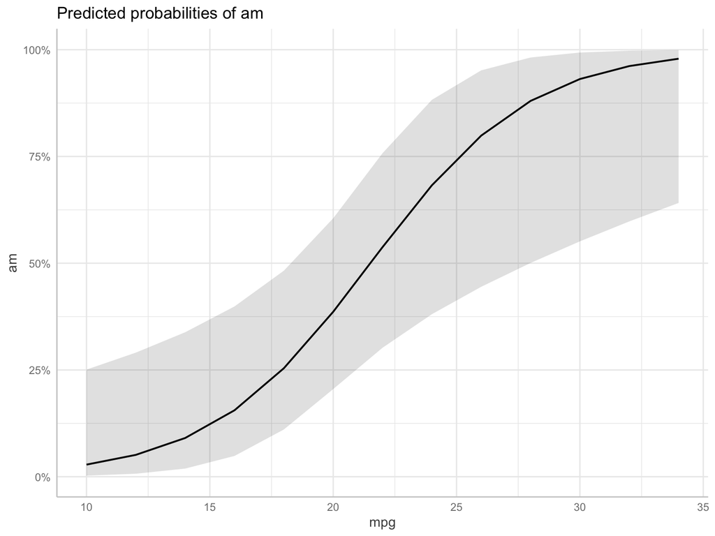

```r
mod_example <- glm(am ~ mpg , data = mtcars, family = 'binomial') #no odds ratio

ggpredict(mod_example) %>% plot()
```

# Summary

- When testing we should usually present effect estimates and 95% CIs as well as p-values
- Type of test depends on outcome/exposure variable type, but workflow is similar in R
- Generally speaking, regression models can be viewed as extensions of simple tests, and can always be used as a substitute